# Import Essential Libraries

```python
import pandas as pd
import numpy as np
import matplotlib.pyplot as plt
import seaborn as sns
%matplotlib inline
```

```python
from sklearn.linear_model import LinearRegression
```

# Read in Data

```python
# Read in most recent version of Approved Loan Data
approved_df = pd.read_csv('E:/josh_data_science\Lending Club Loan Data/approved_loan_data_ver3.csv',
                          encoding='ISO-8859-1', low_memory=False)
```

```python
# Read in most recent version of Approved Loan Data
declined_df = pd.read_csv('E:/josh_data_science\Lending Club Loan Data/declined_loan_data_ver3.csv', encoding='ISO-8859-1')
```

```python
# Remove Unnecessarily created column
del approved_df['Unnamed: 0']
del declined_df['Unnamed: 0']
```

We have seen in the previous notebook that, among the variables that exist in both the approved loans and declined loans data, the credit risk score is incomparable across these two groups because one uses letter grades while the other uses numerical values (FICO score). Before we fit logistic regression or some kind of classification algorithms onto the data, I want to check if the variation in credit risk variable is explained well by the other variables. That is, **I want to check if credit risk is multicollinear with other variables of interest.**

# Relationship between Credit Risk and other variables in Declined Loans Data

```python
# Keeping only the variables we are interested in
approved_df2 = approved_df.copy()[['issue_d','issue_d_year','issue_d_month','loan_amnt','dti','emp_length',
                                'zip_code','addr_state',]]
```

```python
# Keeping only the variables we are interested in
declined_df2 = declined_df.copy()[['Application Date','Amount Requested','dti','Employment Length',
                                 'Zip Code','State','Risk_Score']]
```

##### Divide data by Employment Length

```python
# Borrowers with Less than 1 year of employment
declined_df2_less_1year = declined_df2.copy()[declined_df2.copy()['Employment Length'] == '< 1 year']
```

```python
# Borrowers with 1 year of employment
declined_df2_1year = declined_df2.copy()[declined_df2.copy()['Employment Length'] == '1 year']
```

```python
# Borrowers with 2 years of employment
declined_df2_2year = declined_df2.copy()[declined_df2.copy()['Employment Length'] == '2 years']
```

```python
# Borrowers with 3 years of employment
declined_df2_3year = declined_df2.copy()[declined_df2.copy()['Employment Length'] == '3 years']
```

```python
# Borrowers with 4 years of employment
declined_df2_4year = declined_df2.copy()[declined_df2.copy()['Employment Length'] == '4 years']
```

```python
# Borrowers with 5 years of employment
declined_df2_5year = declined_df2.copy()[declined_df2.copy()['Employment Length'] == '5 years']
```

```python
# Borrowers with 6 years of employment
declined_df2_6year = declined_df2.copy()[declined_df2.copy()['Employment Length'] == '6 years']
```

```python
# Borrowers with 7 years of employment
declined_df2_7year = declined_df2.copy()[declined_df2.copy()['Employment Length'] == '7 years']
```

```python
# Borrowers with 8 years of employment
declined_df2_8year = declined_df2.copy()[declined_df2.copy()['Employment Length'] == '8 years']
```

```python
# Borrowers with 9 years of employment
declined_df2_9year = declined_df2.copy()[declined_df2.copy()['Employment Length'] == '9 years']
```

```python
# Borrowers with 10 years of employment
declined_df2_10year = declined_df2.copy()[declined_df2.copy()['Employment Length'] == '10 years']
```

```python
# Borrowers with more than 10 years of employment
declined_df2_10year_more = declined_df2.copy()[declined_df2.copy()['Employment Length'] == '10+ years']
```

###### Risk_Score v.s. Amount Requested (holding Employment Length Constant)

```
(0, 150000)
```

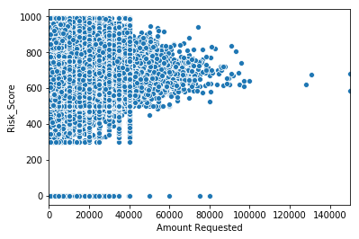

```python
# Risk_Score v.s. Amount Requested (Not controlling for employment length)
sns.scatterplot(x='Amount Requested',y='Risk_Score',data=declined_df2)
plt.xlim(0,150000)
```

```
(0, 80000)
```

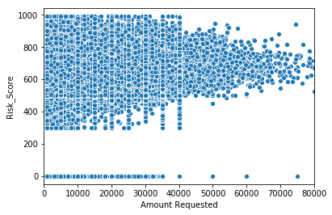

```python
# Risk_Score v.s. Amount Requested (employment length less than 1 year)
sns.scatterplot(x='Amount Requested',y='Risk_Score',data=declined_df2_less_1year)
plt.xlim(0,80000)
```

```
(0, 80000)
```

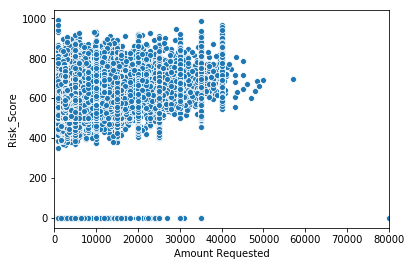

```python
# Risk_Score v.s. Amount Requested (employment length 1 year)
sns.scatterplot(x='Amount Requested',y='Risk_Score',data=declined_df2_1year)
plt.xlim(0,80000)
```

```
(0, 80000)
```

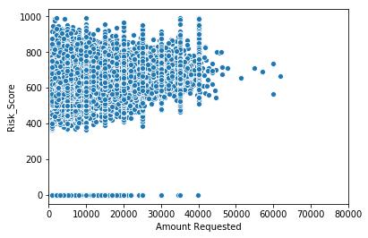

```python
# Risk_Score v.s. Amount Requested (employment length 2 years)
sns.scatterplot(x='Amount Requested',y='Risk_Score',data=declined_df2_2year)
plt.xlim(0,80000)
```

```
(0, 80000)
```

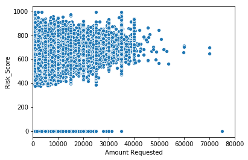

```python
# Risk_Score v.s. Amount Requested (employment length 3 years)
sns.scatterplot(x='Amount Requested',y='Risk_Score',data=declined_df2_3year)
plt.xlim(0,80000)
```

```
(0, 80000)
```

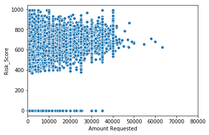

```python
# Risk_Score v.s. Amount Requested (employment length 4 years)
sns.scatterplot(x='Amount Requested',y='Risk_Score',data=declined_df2_4year)
plt.xlim(0,80000)
```

```
(0, 80000)
```

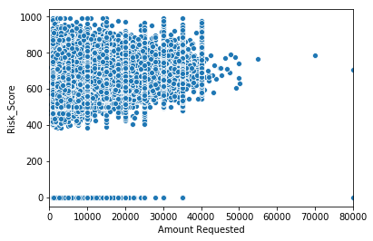

```python
# Risk_Score v.s. Amount Requested (employment length 5 years)
sns.scatterplot(x='Amount Requested',y='Risk_Score',data=declined_df2_5year)
plt.xlim(0,80000)
```

```
(0, 80000)
```

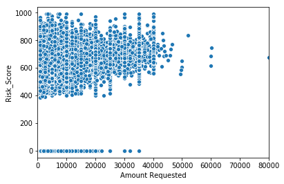

```python
# Risk_Score v.s. Amount Requested (employment length 6 years)
sns.scatterplot(x='Amount Requested',y='Risk_Score',data=declined_df2_6year)
plt.xlim(0,80000)
```

```
(0, 80000)
```

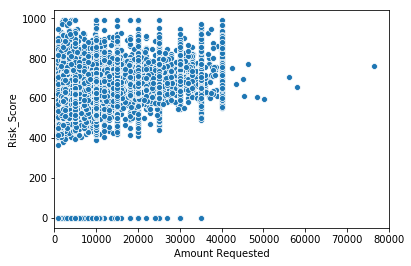

```python
# Risk_Score v.s. Amount Requested (employment length 7 years)
sns.scatterplot(x='Amount Requested',y='Risk_Score',data=declined_df2_7year)
plt.xlim(0,80000)
```

```
(0, 80000)
```

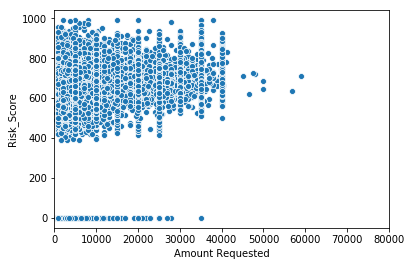

```python
# Risk_Score v.s. Amount Requested (employment length 8 years)
sns.scatterplot(x='Amount Requested',y='Risk_Score',data=declined_df2_8year)
plt.xlim(0,80000)
```

```
(0, 80000)
```

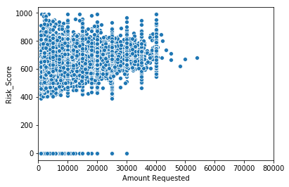

```python
# Risk_Score v.s. Amount Requested (employment length 9 years)
sns.scatterplot(x='Amount Requested',y='Risk_Score',data=declined_df2_9year)
plt.xlim(0,80000)
```

```
(0, 80000)
```

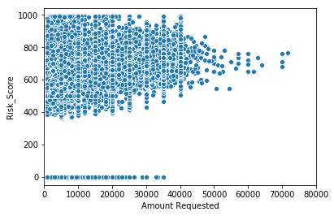

```python
# Risk_Score v.s. Amount Requested (employment length 10 years or more)
sns.scatterplot(x='Amount Requested',y='Risk_Score',data=declined_df2_10year_more)
plt.xlim(0,80000)
```

```python
# Keeping only rows that have data on both risk score and amount requested so that we can use it for simple linear regression
declined_df2_amount = declined_df2.copy()[declined_df2.copy().Risk_Score.notnull()]
declined_df2_amount = declined_df2_amount.copy()[declined_df2_amount.copy()['Amount Requested'].notnull()]
```

```python
lr_amount_request = LinearRegression()
```

```python
lr_amount_request.fit(declined_df2_amount['Amount Requested'].values.reshape(len(declined_df2_amount),1),
                      declined_df2_amount['Risk_Score'].values.reshape(-1,1))
```

```
LinearRegression(copy_X=True, fit_intercept=True, n_jobs=1, normalize=False)
```

```python
# Coefficient of Amount Requested
lr_amount_request.coef_
```

```
array([[ 0.00202309]])
```

```python
#  coefficient of determination R-Squared
lr_amount_request.score(declined_df2_amount['Amount Requested'].values.reshape(len(declined_df2_amount),1),
                       declined_df2_amount['Risk_Score'].values.reshape(-1,1))
```

```
0.059756818686692248
```

###### Risk_Score v.s. DTI (holding Employment Length Constant)

```
(0, 3000000)
```

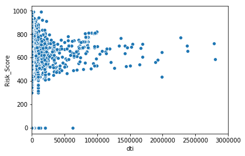

```python
# Risk_Score v.s. DTI (Not controlling for Employment Length)
sns.scatterplot(x='dti',y='Risk_Score',data=declined_df2)
plt.xlim(0, 3000000)
```

```
(0, 3000000)
```

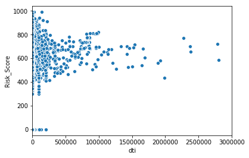

```python
# Risk_Score v.s. DTI (Employment Length less than 1 year)
sns.scatterplot(x='dti',y='Risk_Score',data=declined_df2_less_1year)
plt.xlim(0, 3000000)
```

```
(0, 1000)
```

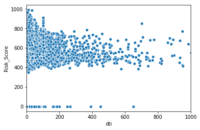

```python
# Risk_Score v.s. DTI (Employment Length less than 1 year)
sns.scatterplot(x='dti',y='Risk_Score',data=declined_df2_1year)
plt.xlim(0, 1000)
```

```
(0, 1000)
```

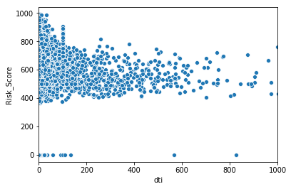

```python
# Risk_Score v.s. DTI (Employment Length less than 2 years)
sns.scatterplot(x='dti',y='Risk_Score',data=declined_df2_2year)
plt.xlim(0, 1000)
```

```
(0, 1000)
```

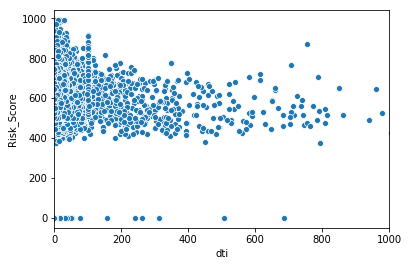

```python
# Risk_Score v.s. DTI (Employment Length less than 3 years)
sns.scatterplot(x='dti',y='Risk_Score',data=declined_df2_3year)
plt.xlim(0, 1000)
```

```
(0, 1000)
```

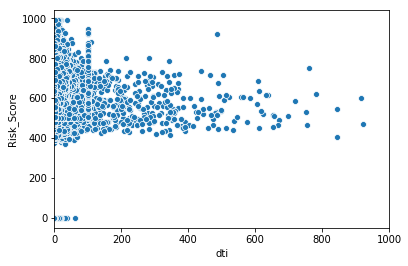

```python
# Risk_Score v.s. DTI (Employment Length less than 4 years)
sns.scatterplot(x='dti',y='Risk_Score',data=declined_df2_4year)
plt.xlim(0, 1000)
```

```
(0, 1000)
```

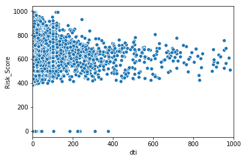

```python
# Risk_Score v.s. DTI (Employment Length less than 5 years)
sns.scatterplot(x='dti',y='Risk_Score',data=declined_df2_5year)
plt.xlim(0, 1000)
```

```
(0, 1000)
```

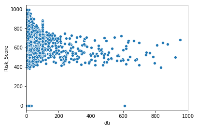

```python
# Risk_Score v.s. DTI (Employment Length less than 5 years)
sns.scatterplot(x='dti',y='Risk_Score',data=declined_df2_6year)
plt.xlim(0, 1000)
```

```
(0, 1000)
```

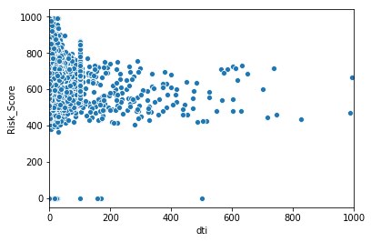

```python
# Risk_Score v.s. DTI (Employment Length less than 7 years)
sns.scatterplot(x='dti',y='Risk_Score',data=declined_df2_7year)
plt.xlim(0, 1000)
```

```
(0, 1000)
```

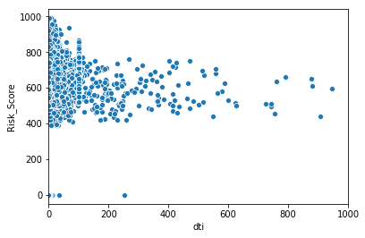

```python
# Risk_Score v.s. DTI (Employment Length less than 8 years)
sns.scatterplot(x='dti',y='Risk_Score',data=declined_df2_8year)
plt.xlim(0, 1000)
```

```
(0, 1000)
```

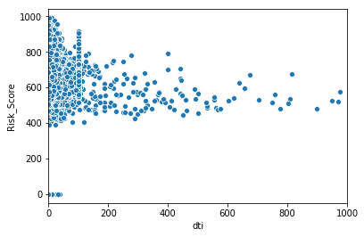

```python
# Risk_Score v.s. DTI (Employment Length less than 9 years)
sns.scatterplot(x='dti',y='Risk_Score',data=declined_df2_9year)
plt.xlim(0, 1000)
```

```
(0, 1000)
```

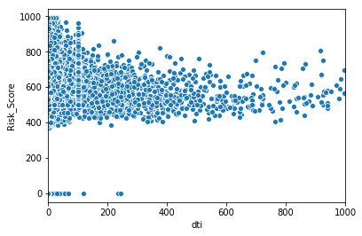

```python
# Risk_Score v.s. DTI (Employment Length less than 10 years)
sns.scatterplot(x='dti',y='Risk_Score',data=declined_df2_10year_more)
plt.xlim(0, 1000)
```

```python
# Keeping only rows that have data on both risk score and dti so that we can use it for simple linear regression
declined_df2_dti = declined_df2.copy()[declined_df2.copy().Risk_Score.notnull()]
declined_df2_dti = declined_df2_dti.copy()[declined_df2_dti.copy()['dti'].notnull()]
```

```python
lr_dti = LinearRegression()
```

```python
lr_dti.fit(declined_df2_dti['dti'].values.reshape(len(declined_df2_dti),1),
                      declined_df2_dti['Risk_Score'].values.reshape(-1,1))
```

```
LinearRegression(copy_X=True, fit_intercept=True, n_jobs=1, normalize=False)
```

```python
# Coefficient of dti
lr_dti.coef_
```

```
array([[ -8.91752588e-06]])
```

```python
#  coefficient of determination R-Squared
lr_dti.score(declined_df2_dti['dti'].values.reshape(len(declined_df2_dti),1),
                      declined_df2_dti['Risk_Score'].values.reshape(-1,1))
```

```
3.1429241807989783e-06
```

###### Risk Score v.s. Employment Length

```
([0, 1, 2, 3, 4, 5, 6, 7, 8, 9, 10], <a list of 11 Text xticklabel objects>)
```

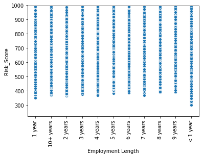

```python
sns.scatterplot(x='Employment Length',y='Risk_Score',data=declined_df2)
plt.ylim(220,999)
plt.xticks(rotation=90)
```

```python
# Encode the column into numerical data
declined_df2['Employment Length Encoded'] = declined_df2['Employment Length'].replace({'1 year': 1, '< 1 year': 0.5, '2 years':2,
                                                                                          '3 years':3,'4 years':4,'5 years':5,
                                                                                          '6 years':6,'7 years':7,'8 years':8,
                                                                                          '9 years':9,'10+ years':10})
```

```python
# Keeping only rows that have data on both risk score and employment Length so that we can use it for simple linear regression
declined_df2_empLength = declined_df2.copy()[declined_df2.copy().Risk_Score.notnull()]
declined_df2_empLength = declined_df2_empLength.copy()[declined_df2_empLength.copy()['Employment Length Encoded'].notnull()]
```

```python
lr_empLength = LinearRegression()
```

```python
lr_empLength.fit(declined_df2_empLength['Employment Length Encoded'].values.reshape(len(declined_df2_empLength),1),
                      declined_df2_empLength['Risk_Score'].values.reshape(-1,1))
```

```
LinearRegression(copy_X=True, fit_intercept=True, n_jobs=1, normalize=False)
```

```python
# Coefficient of dti
lr_empLength.coef_
```

```
array([[ 6.53309532]])
```

```python
# coefficient of determination R-Squared
lr_empLength.score(declined_df2_empLength['Employment Length Encoded'].values.reshape(len(declined_df2_empLength),1),
                      declined_df2_empLength['Risk_Score'].values.reshape(-1,1))
```

```
0.016612198079983487
```

After fitting Simple Linear Regression on each of Risk Score v.s. other variable of interest (requested loan amount, dti, employment length), I discovered that individual variables don't really explain well the variation in risk score. Each of the variable is not that mutlicollinear with risk score. Then, **the question is does the combination of those three variables explain well the variation in risk score?**

```python
# Keeping only rows that have data on both risk score, amount requested, dti, employment Length so that
# we can use it for simple linear regression
declined_df2_all_three = declined_df2.copy()[declined_df2.copy().Risk_Score.notnull()]
declined_df2_all_three = declined_df2_all_three.copy()[declined_df2_all_three.copy()['Employment Length Encoded'].notnull()]
declined_df2_all_three = declined_df2_all_three.copy()[declined_df2_all_three.copy()['Amount Requested'].notnull()]
declined_df2_all_three = declined_df2_all_three.copy()[declined_df2_all_three.copy()['dti'].notnull()]
```

```python
lr_all_three = LinearRegression()
```

```python
lr_all_three.fit(declined_df2_all_three[['Amount Requested','dti','Employment Length Encoded']].values.reshape(len(declined_df2_all_three),3),
                      declined_df2_all_three['Risk_Score'].values.reshape(-1,1))
```

```
LinearRegression(copy_X=True, fit_intercept=True, n_jobs=1, normalize=False)
```

```python
# Coefficient of dti
lr_all_three.coef_
```

```
array([[  1.96059442e-03,  -9.25781787e-06,   5.73066386e+00]])
```

```python
# coefficient of determination R-Squared
lr_all_three.score(declined_df2_all_three[['Amount Requested','dti','Employment Length Encoded']].values.reshape(len(declined_df2_all_three),3),
                      declined_df2_all_three['Risk_Score'].values.reshape(-1,1))
```

```
0.07248597426174197
```

**Even when three of the variables are considered for together in the model, the MLR model only explains 7.2% of the variation in Risk Score**

# Save modified file

```python
# Encode the column into numerical data
declined_df['Employment Length Encoded'] = declined_df['Employment Length'].replace({'1 year': 1, '< 1 year': 0.5, '2 years':2,
                                                                                          '3 years':3,'4 years':4,'5 years':5,
                                                                                          '6 years':6,'7 years':7,'8 years':8,
                                                                                          '9 years':9,'10+ years':10})
```

```python
declined_df.to_csv('E:/josh_data_science\Lending Club Loan Data/declined_loan_data_ver4.csv', encoding='ISO-8859-1')
```